# DDP Week 4 Assignment

Dr. Rich Huebner

February 2, 2018

## Welcome and Introduction

This presentation discusses the final Week 4 project for the Coursera course called, Developing Data Products.

The instructions are to design and implement a shiny app that also makes use of the plotly library, and does so in a creative way.

I am using a specialized data set regarding HR. The data set was developed by Dr. Rich Huebner and is available at Kaggle here: https://www.kaggle.com/rhuebner/human-resources-data-set/data

All of the code is also available here, under my github account.

https://github.com/RHuebner1972/ddp_final_project

## Background Information

- The HR data set was created specifically for HR students to explore data visualization techniques.
- HR students grab the data set and explore the different features, and learn how to create the visualizations in Tableau.
- The data set has numerous features, but I only use a few of them in the Shiny app to demonstrate the types of things we could do.

## Features used within the data.

This app will use three features from the HR data set:

- Department
- Pay Rate (Loaded in a data frame as Pay.Rate)
- Age

Of course there won’t be a relationship between Pay Rate and Age, but still thought it would be interesting to plot them, based on Department. Perhaps there are some patterns that could emerge, or you might learn something new about the data.

## Where can you see the app “live” and play around with it ?

Here is the location of the actual application, that uses shiny and plotly.

https://richhuebner.shinyapps.io/hr-app1/

- To use the application, you can slide the slider to select the number of bins for the histogram.
- Changing the number of bins results in immediate (reactive) changes to the histogram.
- Also, you can select a different department from the drop-down menu, and the histogram and plotly plot will update accordingly.

Look for differences across departments.

Are there any relationships or patterns that you see?

## Sample output from the app - Histogram

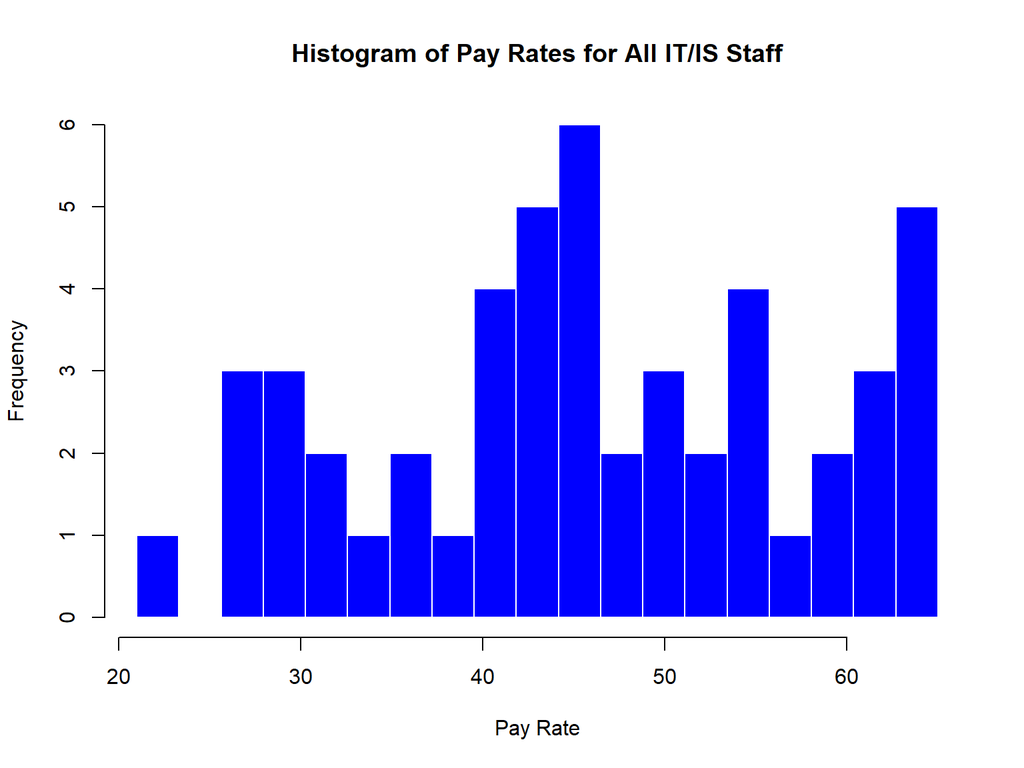

## Plot output

[interactive chart not shown]

## Further information

Further information about the data set can be retrieved from Kaggle, or by contacting Dr. Rich Huebner.

- Dr. Rich Huebner
- Rich.Huebner@yahoo.com

Thank you!